# Lab 3: Hip-Hop Lyrics

- Show All Code
- Hide All Code
- View Source

Author

Daltzwer Oliveros

# Getting Started

Download starter .qmd file

**Add your preferred YAML**

The downloaded file **does not** contain an YAML, you need to include your own. This allows you to specify how you would like your rendered HTML to look! The sky is the limit!

Download `hiphop.csv`

**Warning**

Save **both** your .qmd file and your data set in the same folder within your Stat 331 directory! **DO NOT** open your .qmd file straight from your downloads folder.

## Tips for Formatting your Lab

**Tip**

- The first chunk of your Quarto document should be to *declare your libraries* (probably only `tidyverse` for now).
- The second chunk of your Quarto document should be to *load in your data* (using the `here()` function!).
- Make sure you address **all the questions** in these instructions.
- If a question requires **any** type of calculation, **you should provide code for your answer!**
- I have provided hints about functions that might be useful to you. You are **not required** to use these functions.
- You may have to Google to solve some of these!
- Be sure to **save** your work regularly (`Ctrl/Cmd + S` or `File > Save` or the floppy disk icon)
- Be sure to **render** your file every so often, to check for errors and make sure it looks nice.
  - Make your Quarto document does not contain `View(dataset)` or `install.packages("package")`, both of these will prevent rendering.
  - Check your Quarto document for moments when you looked at the data by typing the name of the data frame. Leaving these in means the whole dataset will print out and this looks unprofessional.
  - If you are unable to finish due to errors in your code, remember that you can still submit an HTML file if you specify `error: true` in your `execute` options (in the YAML).

# Data Set

The data set `hiphop` contains results from a study conducted by a linguist at the University of Minnesota. The researcher was interested in predicting musical taste based on familiarity with African American English (AAE). 168 subjects participated in the study, and each was asked to define 64 different AAE terms. The definitions given were used to create a `familiarity` score for each subject for each term. This score quantifies how well the subject knew the term on a scale of 1-5 (1 = not at all, 5 = very well). Before tackling the problems, study the description of each variable [here](http://conservancy.umn.edu/bitstream/handle/11299/116327/5/explanationAAEHiphopChesley.txt).

**1. Load the appropriate R packages and import the data set, `hiphop`.**

```r
# code chunk for loading packages and importing the data
library(tidyverse)
library(here)
hiphop <- read.csv(here("Week 3", "Lab", "hiphop.csv"))
```

## Summary

**2. Provide a brief overview (2-4 sentences) of the data set.**

```r
# you may want to use code to answer this question
dim(hiphop)
```

```
[1] 10752    38
```

```r
view(hiphop)
names(hiphop)
```

```
 [1] "word"                "subj"                "sex"
 [4] "age"                 "ethnic"              "city"
 [7] "county"              "intl"                "vocal"
[10] "classical"           "folk"                "rock"
[13] "country"             "pop"                 "alternative"
[16] "hiphop"              "unclassifiable"      "countyBlack"
[19] "jayz"                "barkley"             "boondocks"
[22] "monique"             "bieber"              "asianMove"
[25] "blackMove"           "hispanicMove"        "nativeMove"
[28] "SAAMEMove"           "whiteMove"           "blackWeekly"
[31] "jayz1"               "boondocks1"          "familiarity"
[34] "trial"               "fam1"                "popularityScore"
[37] "numPreferredArtists" "numOverallArtists"
```

```r
str(hiphop)
```

```
'data.frame':   10752 obs. of  38 variables:
 $ word               : chr  "[to be] ghost" "[to be] ghost" "[to be] ghost" "[to be] ghost" ...
 $ subj               : chr  "p15" "p53" "p136" "p36" ...
 $ sex                : chr  "Female" "Female" "Male" "Female" ...
 $ age                : int  20 17 41 18 18 19 18 18 19 19 ...
 $ ethnic             : chr  "white" "white" "white" "white" ...
 $ city               : num  33283 34033 8789 712 24280 ...
 $ county             : num  1156212 396500 58696 148955 153504 ...
 $ intl               : int  0 0 0 0 0 0 0 0 0 0 ...
 $ vocal              : int  0 0 2 0 3 0 0 0 0 1 ...
 $ classical          : int  0 0 0 0 3 0 0 0 0 0 ...
 $ folk               : int  0 0 0 1 0 0 2 0 0 0 ...
 $ rock               : int  1 0 0 1 1 0 0 1 0 4 ...
 $ country            : int  3 1 0 2 0 1 0 3 0 4 ...
 $ pop                : int  4 3 0 2 3 1 0 1 0 4 ...
```

[output cut: 24 more lines]

```r
#in this data set,the researcher was trying to identify whether they can predict musical taste based on their familiarity with African American English (AAE). In total, there were 38 variables that were being considered such as sex, age, and city.
```

**Note**

It is always good practice to start an analysis by getting a feel for the data and providing a quick summary for readers. You do not need to show any source code for this question, although you probably want to use code to get some information about the data set.

**3. What are the rows of this data set?**

**Warning**

It is not one person per row!

```r
# you may want to use code to answer this question


nrow(hiphop)
```

```
[1] 10752
```

The rows of the data seems to represent 10,752 different AAE word/person combo.

## Cleaning the Data

**4. Missing values for some of the variables were replaced with other values. How were missing values replaced? What do you believe are some benefits and drawbacks of doing this?**

```r
# you may want to use code to answer this question
```

Missing values were replaced by their mean. By filling in missing values, you get more data to work with to help us with our research. However, it is not a reflection of the actual idea but our best guess.

**5. Clean the data set in whichever ways you see fit. This might mean adjusting *variable type*, for example from `character` to `factor`, or dealing with missing data. Assign your cleaned data set to a new data set named `hiphop_clean` – use this data set going forward.**

**Tip**

Helpful functions: `mutate()`, `as.factor()`

Likert scales (1-5) will be read by R as numeric values and MUST be converted to factors.

It would be most efficient to use `across()` in combination with `mutate()` to complete this task.

```r
# code chunk for Q5
hiphop_clean <- hiphop |>
  mutate(across(c(jayz, jayz1, barkley, boondocks, boondocks1, monique, bieber),
                as.factor))
str(hiphop_clean)
```

```
'data.frame':   10752 obs. of  38 variables:
 $ word               : chr  "[to be] ghost" "[to be] ghost" "[to be] ghost" "[to be] ghost" ...
 $ subj               : chr  "p15" "p53" "p136" "p36" ...
 $ sex                : chr  "Female" "Female" "Male" "Female" ...
 $ age                : int  20 17 41 18 18 19 18 18 19 19 ...
 $ ethnic             : chr  "white" "white" "white" "white" ...
 $ city               : num  33283 34033 8789 712 24280 ...
 $ county             : num  1156212 396500 58696 148955 153504 ...
 $ intl               : int  0 0 0 0 0 0 0 0 0 0 ...
 $ vocal              : int  0 0 2 0 3 0 0 0 0 1 ...
 $ classical          : int  0 0 0 0 3 0 0 0 0 0 ...
 $ folk               : int  0 0 0 1 0 0 2 0 0 0 ...
 $ rock               : int  1 0 0 1 1 0 0 1 0 4 ...
 $ country            : int  3 1 0 2 0 1 0 3 0 4 ...
 $ pop                : int  4 3 0 2 3 1 0 1 0 4 ...
```

[output cut: 24 more lines]

# Data Summaries

**6. How many unique AAE words were studied in this data set?**

**Tip**

Helpful functions: `distinct()`, `count()`

```r
# code chunk for Q6
hiphop_clean|>
  distinct(word) |>
  pull(word) |>
  length()
```

```
[1] 64
```

```r
#there are 64 unique words in this dataset
```

**7. Make a new variable that re-categorizes `ethnic` into only two groups, “white” and “non-white”, to simplify your data.**

**Tip**

Helpful functions: `mutate()`, `if_else()`

```r
# code chunk for Q7
hiphop_clean = hiphop_clean |>
  mutate(ethnic1 = if_else(ethnic == "white", "white", "non-white"))
```

**8. It is fairly common for researchers to collapse ethnic or racial categories similar to what you just did. What are some issues with representing the data in this way?**

```r
#collapsing ethnic/racial categories into "white and non-white" misrepresents the other racial groups that are being studied or surveyed. Addiotionally, this gives the unintentional message that the only ethnic group worth naming are "whites" as evidenced by the categorization of other racial groups as simply "non-white".
```

**9. What are the demographics of the people in this study? Investigate the variables `sex`, `age`, and `ethnic` and summarize your findings in 1-3 complete sentences.**

**Tip**

You’ll need to first manipulate your data to have each person represented only once.

Helpful functions: `select()`, `distinct(___, .keep_all = TRUE)`, `count()`, `summary()`

```r
# code chunk for Q9
demodata <- hiphop_clean |>
  select(subj, age, sex, ethnic1) |>
  distinct(subj, .keep_all = TRUE)
demodata |>
  count(sex)
```

```
     sex   n
1 Female 117
2   Male  51
```

```r
demodata |>
  summarise(mean_age = mean(age),
            sd_age = sd(age))
```

```
  mean_age   sd_age
1 20.02381 4.746196
```

```r
demodata |>
  count(ethnic1)
```

```
    ethnic1   n
1 non-white  33
2     white 135
```

**10. Make at least two plots to display the demographic information of the subjects in this study.**

**Note**

You do not need to discuss these plots, but make sure they are appropriate to the data types and have informative titles and axis labels. Feel free to use the skills you learned in Challenge 2 to enhance your plots!

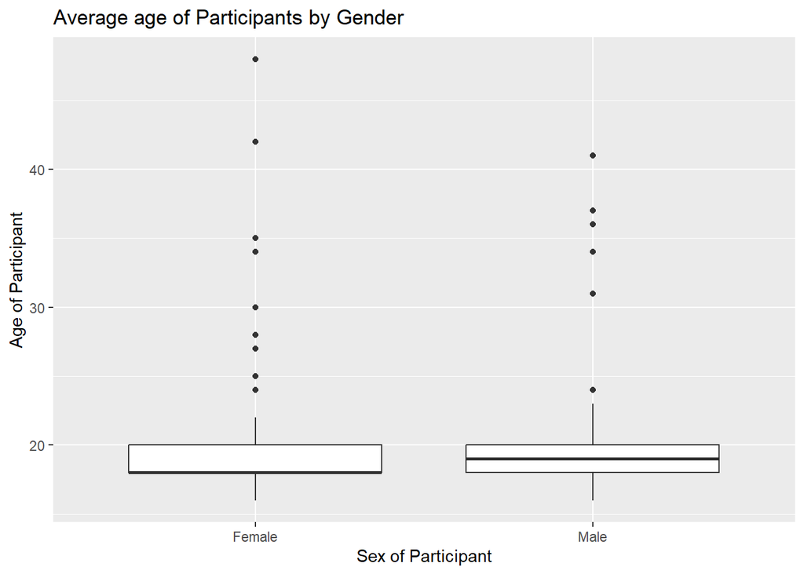

```r
# code chunk for Q10


ggplot(data = hiphop_clean,
       mapping = aes(x = sex,
                     y = age)) +
  geom_boxplot() +
  labs( x = "Sex of Participant",
        y = "Age of Participant",
        title = "Average age of Participants by Gender")
```

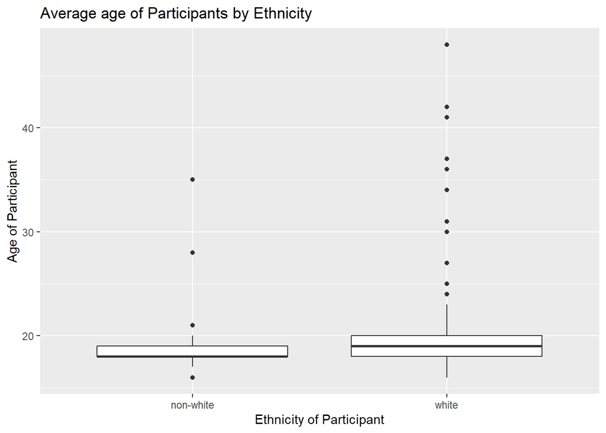

```r
ggplot(data = hiphop_clean,
       mapping = aes(x = ethnic1,
                     y = age)) +
  geom_boxplot() +
  labs( x = "Ethnicity of Participant",
        y = "Age of Participant",
        title =  "Average age of Participants by Ethnicity")
```

## Familiar words

For each demographic group listed below, determine which word(s) in this study was(were) the most **and** least familiar on average.

**Tip**

Helpful functions: `filter()`, `group_by()`, `summarize()`, `slice_max()`, `slice_min()`

Useful variables: `word`, `familiarity`, `sex`, `age`, `ethnic`

**11. People below the age of 20.**

```r
# code chunk for Q11

subj_fam <- hiphop_clean |>
  filter( age < 20) |>
  group_by(word) |>
  summarise(mean_fam = mean(familiarity))

subj_fam|>
  slice_min(mean_fam)
```

```
# A tibble: 1 × 2
  word             mean_fam
  <chr>               <dbl>
1 catch the vapors     1.03
```

```r
subj_fam|>
  slice_max(mean_fam)
```

```
# A tibble: 1 × 2
  word         mean_fam
  <chr>           <dbl>
1 off the hook     4.42
```

According to the data, “off the hook” is the word/phrase people who are below the age 20 are most familiar with with an average score of 4.4237 and “catch the vapor” is the word/phrase poeple are the least familiar with with an average score of 1.0254.

**12. Non-white women.**

```r
# code chunk for Q12

nw_women_fam <- hiphop_clean |>
  filter( ethnic1 == "non-white", sex == "Female") |>
  group_by(word) |>
  summarise(mean_fam = mean(familiarity))

nw_women_fam|>
  slice_min(mean_fam)
```

```
# A tibble: 4 × 2
  word              mean_fam
  <chr>                <dbl>
1 break someone out        1
2 dukey rope               1
3 plex                     1
4 rollie                   1
```

```r
nw_women_fam|>
  slice_max(mean_fam)
```

```
# A tibble: 1 × 2
  word    mean_fam
  <chr>      <dbl>
1 feel me     4.19
```

According to the data above, non-white women are most familiar with the phrase “feel me” with an average score of 4.19 while break someone out, dukey rope, plex, and rollie were all tied for the phrases non-white women are most unfamiliar with with an average score of just 1.

**13. White men above the age of 30.**

```r
# code chunk for Q13

w_men_fam <- hiphop_clean |>
  filter( ethnic1 == "white",
          sex == "Male", age > 30) |>
  group_by(word) |>
  summarise(mean_fam = mean(familiarity))

w_men_fam|>
  slice_min(mean_fam)
```

```
# A tibble: 25 × 2
   word              mean_fam
   <chr>                <dbl>
 1 ay yo trip               1
 2 beezy                    1
 3 break someone out        1
 4 catch the vapors         1
 5 crossroads               1
 6 crump                    1
 7 dap                      1
 8 dollar cab               1
 9 domino                   1
10 duckets                  1
# … with 15 more rows
```

```r
w_men_fam|>
  slice_max(mean_fam)
```

```
# A tibble: 1 × 2
  word  mean_fam
  <chr>    <dbl>
1 5-0        4.2
```

According to the data above, there were a number of phrases that white men above 30 are unfamiliar with which includes, ay yo trip, beezy, and dap just to name a few. In total, there were 25 phrases that were tied that white men above 30 are unfamiliar with with an average score of just 1. Meanwhile, they were most familiar with the phrase 5-0, which had an average score of 4.2.

## Study Subjects

A joke among the [Tidy Tuesday](https://www.tidytuesday.com/) community is that Justin Bieber was one of the subjects in this study. Bieber, a white male, from a relatively small town (10,000-60,000 people) in Ontario would have been 17-23 at the time of the study.

**14. Determine which subject you believe is secretly Bieber, justify your answer.**

**Tip**

Refer again to the data set description. There is another clue about Bieber’s identity.

```r
# code chunk for Q14
hiphop_clean |>
  filter(ethnic1 == "white",
         sex == "Male",
         age %in% 17:23,
         city >= 10000 & city <= 60000,
         bieber == 5) |>
  distinct(subj)
```

```
  subj
1  p17
```

Intrestingly, we filtered according to the data and clues expecting the last person to score a 6 on the bieber song scale but there was no one. We did, however, find p17 who scored a 5 which leads us to believe that this must be Justin Bieber based on the data and hints provided above.

# Lab 3 Submission

You will submit **only** your rendered HTML file. Your HTML file is required to have the following specifications in the YAML options (at the top of your document):

- be self-contained (`self-contained: true`)
- include your source code (`code-tools: true`)
- include all your code and output (`echo: true`)
- include **no** messages from loading in packages or the data (`messages: false`)

**If any of the options are not included, your Lab 3 or Challenge 3 assignment will receive an “Incomplete” and you will be required to submit a revision.**

# Challenge 3: Group Comparisons & Data Ethics

## Published Comparisons

In the published article ([You Know What It Is: Learning Words through Listening to Hip-Hop](https://journals.plos.org/plosone/article/file?id=10.1371/journal.pone.0028248&type=printable)), the author presents a series of comparisons about the variables which most explain an individual’s familiarity with African American English (AAE).

Let us instead compare the number of artists participants reported liking for each genre. Specifically, you will determine which music genre most differentiates each of the demographic groups provided.

> Which genre had much higher average (mean or median) reported artists in one group than the other.
> - Male versus Female
> - White versus Non-White

**Tip**

You might find it helpful to first create a new data set with only the variables you are interested in! Look at the Music Variables in the data set description along with the demographics of interest.

Helpful functions: `select()`, `group_by()`, `summarize()`, `across()`

Other useful operations in R: `mean()`, `diff()`, `abs()`, `which.max()`

## Study Design Critique – Data Ethics

Myself, members of the Tidy Tuesday community, and previous 331 students have voiced concerns regarding the design and social context of this study.

You’ve already read the [data description (link)](http://conservancy.umn.edu/bitstream/handle/11299/116327/5/explanationAAEHiphopChesley.txt) regarding how participants were recruited for participation in this study. **Now**, you need to read additional details regarding aspects of the study in the published paper: [You Know What It Is: Learning Words through Listening to Hip-Hop](https://journals.plos.org/plosone/article/file?id=10.1371/journal.pone.0028248&type=printable).

> Based on the design of this study and its context (African American English), what are **at least two** concerns you have? Keep in mind this critique aligns with conversations regarding data ethics. Thus, your concerns need to address the racial aspects of the design of this study.

# Challenge 3 Submission

Your challenge should be submitted as a **separate file**, **not** at the bottom of your Lab 3 file. Please submit your rendered HTML file. You can copy and paste this code into a **new** Quarto file. Your Challenge 3 submission should only included code necessary for completing the Challenge, nothing else.

You will submit **only** your rendered HTML file. Your HTML file is required to have the following specifications in the YAML options (at the top of your document):

- be self-contained (`self-contained: true`)
- include your source code (`code-tools: true`)
- include all your code and output (`echo: true`)
- include **no** messages from loading in packages or the data (`messages: false`)

**If any of the options are not included, your Lab 3 or Challenge 3 assignment will receive an “Incomplete” and you will be required to submit a revision.**